# 简介

该项目是人流密度预测常规赛的一种解决代码，旨在提供一种问题建模的思路，仅供初步的学习和参考。本项目通过端到端的训练CNN网络来提取输入图像的人流密度图，并通过密度图来得到最终的人数统计。具体思路如下：

[figure not shown]

  上图仅为模型的简单表示，具体的卷积核大小，步长等参数可在后续的代码中查看

```python
# 解压数据集
!unzip -q -o data/data1917/train_new.zip
!unzip -q -o data/data1917/test_new.zip
```

```python
# 导入包
import zipfile
import paddle
import paddle.fluid as fluid
import matplotlib.pyplot as plt
import matplotlib.image as mping
from PIL import Image
import json
import numpy as np
import cv2
import sys
import time
import h5py
# import scipy.io as io
from matplotlib import pyplot as plt
from scipy.ndimage.filters import gaussian_filter
import scipy
from matplotlib import cm as CM
from paddle.utils.plot import Ploter
```

```python
start = time.time()
#把图片对应的标签装入字典
f = open('/home/aistudio/data/data1917/train.json',encoding='utf-8')
content = json.load(f)

print(content.keys())
print('info：',content['info'])
print('stage:',content['stage'])
print('split:',content['split'])
print(content['annotations'][0].keys())
print(content['annotations'][0]['type'])
print(content['annotations'][0][ 'id'])
print(content['annotations'][0]['ignore_region'])
print(content['annotations'][0]['name'])
print(content['annotations'][0]['num'])
```

```
dict_keys(['annotations', 'split', 'info', 'stage'])
info： Baidu Star AI Competition 2018
stage: 1
split: train
dict_keys(['num', 'ignore_region', 'name', 'type', 'annotation', 'id'])
bbox
625
[]
stage1/train/61a4091324d1983534ca23b6f007f841.jpg
28
```

```python
#把stage1都去掉：
for j in range(len(content['annotations'])):
    content['annotations'][j]['name'] = content['annotations'][j]['name'].lstrip('stage1').lstrip('/')
print(content['annotations'][1]['name'])
```

```
train/71e5bc76196e91f26426b7facbcc0843.jpg
```

```
train/002be7f228f584630bde7582c9dbaffb.jpg
```

[figure not shown]

```python
#读取解压文件里的信息
zfile = zipfile.ZipFile("data/data1917/train_new.zip")
l = []  # l中存储了train中所有的图片路径
for fname in zfile.namelist()[1:]:
    # print(fname)
    l.append(fname)
print(l[3])
name = l[3]
im = Image.open(name)
plt.imshow(im)
```

```python
#查看标注的信息

for j in range(len(content['annotations'])):
    if content['annotations'][j]['name'] == name:
        print('id = ',content['annotations'][j]['id'])   #图片id
        ann = content['annotations'][j]['annotation']
print(ann)       #图片标注格式是x,y,w,h,有些只有x,y
print('有标注的个数：',len(ann))
#可视化第三个标注的信息
lab = 1
box = (ann[lab]['x'],ann[lab]['y'],ann[lab]['x']+ann[lab]['w'],ann[lab]['y']+ann[lab]['h'])
new_img = im.crop(box=box)
plt.imshow(new_img)
```

[output not shown]

```
id =  668
[{'y': 693, 'h': 373, 'w': 196, 'x': 1108}, {'y': 424, 'h': 448, 'w': 118, 'x': 1009}, {'y': 361, 'h': 249, 'w': 250, 'x': 864}, {'y': 300, 'h': 342, 'w': 104, 'x': 882}, {'y': 128, 'h': 99, 'w': 28, 'x': 846}, {'y': 131, 'h': 86, 'w': 48, 'x': 870}, {'y': 94, 'h': 90, 'w': 22, 'x': 899}, {'y': 97, …
有标注的个数： 23
```

```
1920 1080
```

[figure not shown]

```python
#可视化图片所有标注信息
width = im.size[0]    #获取宽度
height = im.size[1]   #获取长度
print(width,height)
for a in range(len(ann)):        #遍历所有标注
    for x in range(width):
        for y in range(height):
            # r,g,b = im.getpixel((x,y))
            if(x > (ann[a]['x']-5) and x < (ann[a]['x']+5) and y > ann[a]['y'] and y < (ann[a]['y']+ann[a]['h'])):
                im.putpixel((x,y),(255,0,0))        #画一条长(x,y)到(x,y+h)的红线，红线宽为正负5个像素点
            if(x > (ann[a]['x']+ann[a]['w']-5) and x < (ann[a]['x']+ann[a]['w']+5) and y > ann[a]['y'] and y < (ann[a]['y']+ann[a]['h'])):
                im.putpixel((x,y),(255,0,0))       #画一条长(x+w,y)到(x+w,y+h)的红线，红线宽为正负5个像素点
            if(y > (ann[a]['y']-5) and y < (ann[a]['y']+5) and x > ann[a]['x'] and x < (ann[a]['x']+ann[a]['w'])):
                im.putpixel((x,y),(255,0,0))        #画一条长(x,y)到(x+w,y)的红线，红线宽为正负5个像素点
            if(y > (ann[a]['y']+ann[a]['h']-5) and y < (ann[a]['y']+ann[a]['h']+5) and x > ann[a]['x'] and x < (ann[a]['x']+ann[a]['w'])):
                im.putpixel((x,y),(255,0,0))        #画一条长(x,y+h)到(x+w,y+h)的红线，红线宽为正负5个像素点
plt.imshow(im)
```

```python
# 根据图片的大小，对图片的来源进行分类
l_set = []
s_2560_1920 = []   #方框   鱼眼电梯   63张
s_928_576 = []     #点   自动售货机   248张
s_1024_768 = []    #点   街拍        302
s_640_480 = []     #点   家拍        92
s_2048_2048 =[]    #方框   鱼眼电梯   41
s_1080_1618 =[]    #滤掉             1
s_1920_1080 = []   #方框   超市       1240
s_1440_1080 =[]    #滤掉               1
s_1920_1200 =[]    #方框   街拍        12
for inde in range(2000):
    imm = Image.open(content['annotations'][inde]['name'])
    l_set.append(imm.size)
    if imm.size == (2560, 1920):s_2560_1920.append(content['annotations'][inde]['name'])
    elif imm.size == (928, 576):s_928_576.append(content['annotations'][inde]['name'])
    elif imm.size == (1024, 768):s_1024_768.append(content['annotations'][inde]['name'])
    elif imm.size == (640, 480):s_640_480.append(content['annotations'][inde]['name'])
    elif imm.size == (2048, 2048):s_2048_2048.append(content['annotations'][inde]['name'])
    elif imm.size == (1080, 1618):s_1080_1618.append(content['annotations'][inde]['name'])
    elif imm.size == (1920, 1080):s_1920_1080.append(content['annotations'][inde]['name'])
    elif imm.size == (1440, 1080):s_1440_1080.append(content['annotations'][inde]['name'])
    elif imm.size == (1920, 1200):s_1920_1200.append(content['annotations'][inde]['name'])
print(len(l_set))
sett = set(l_set)
print(sett)
print(len(s_2560_1920),len(s_928_576),len(s_1024_768),len(s_640_480),len(s_2048_2048),len(s_1080_1618),len(s_1920_1080),len(s_1440_1080),len(s_1920_1200))
print(s_1440_1080)
print(s_1080_1618)
# print(s_1024_768)
```

```
2000
{(2560, 1920), (928, 576), (1024, 768), (640, 480), (2048, 2048), (1080, 1618), (1920, 1080), (1440, 1080), (1920, 1200)}
63 248 302 92 41 1 1240 1 12
['train/8538edb45aaf7df78336aa5b49001be6.jpg']
['train/377df0a7a9abc44e840e938521df3b54.jpg']
```

```python
# 统计出所有的，以点为图中每个人标注的样本
point_l = []
for f in range(2000):
    if 'w' not in content['annotations'][f]['annotation'][0]:
        point_l.append(content['annotations'][f]['name'])
# for p_name in point_l:
#     print(p_name)
print(len(point_l))
```

```
747
```

```
id =  628
有标注的个数： 7
```

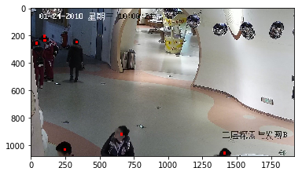

```python
#如果标注是一个坐标不是区域, 展示其中一幅图像上 是如何使用一个点来标注人的
# name1 = 'train/b179764112252559b76a59db9fa18021.jpg'
name1 = point_l[1]
im1 = Image.open(name1)
for j in range(len(content['annotations'])):
    if content['annotations'][j]['name'] == name1:
        print('id = ',content['annotations'][j]['id'])
        ann1 = content['annotations'][j]['annotation']
# print(ann1)
print('有标注的个数：',len(ann1))
for a in range(len(ann1)):
    for x in range(im1.size[0]):
        for y in range(im1.size[1]):
            if(x > (ann1[a]['x']-10) and x < (ann1[a]['x']+10) and y > ann1[a]['y']-10 and y < (ann1[a]['y']+10)):  #取坐标范围正负10的像素
                im1.putpixel((x,y),(255,0,0))           #对所取范围的像素变成红色
plt.imshow(im1)
```

```python
# 上段代码块中的标注的gt
gt = []
for a in range(len(ann1)):
    gt.append([ann1[a]['x'],ann1[a]['y']])
print(gt)
gt = np.array(gt)
print(gt.shape)
```

```
[[43, 257], [98, 206], [333, 247], [102, 236], [247, 1032], [660, 919], [1414, 1057]]
(7, 2)
```

```python
# 使用高斯滤波变换生成密度图
def gaussian_filter_density(gt):
    #Generates a density map using Gaussian filter transformation
    # 初始化密度图
    density = np.zeros(gt.shape, dtype=np.float32)

    # 获取gt中不为0的元素的个数
    gt_count = np.count_nonzero(gt)

    # 如果gt全为0，就返回全0的密度图
    if gt_count == 0:
        return density

    # FInd out the K nearest neighbours using a KDTree

    pts = np.array(list(zip(np.nonzero(gt)[1].ravel(), np.nonzero(gt)[0].ravel())))

    # if gt_count > 0 and gt_count < 20:

    # leafsize = 2048

    # # build kdtree
    # tree = scipy.spatial.KDTree(pts.copy(), leafsize=leafsize)

    # query kdtree
    # distances, locations = tree.query(pts, k=4)

    for i, pt in enumerate(pts):
        pt2d = np.zeros(gt.shape, dtype=np.float32)
        pt2d[pt[1],pt[0]] = 1.
        if gt_count > 1:
            # sigma = (distances[i][1]+distances[i][2]+distances[i][3])*0.1
            sigma = 25
        else:
            sigma = np.average(np.array(gt.shape))/2./2. #case: 1 point

        #Convolve with the gaussian filter

        density += scipy.ndimage.filters.gaussian_filter(pt2d, sigma, mode='constant')

    return density
```

```python
print(gt.shape)

img= plt.imread(name1)
k = np.zeros((img.shape[0],img.shape[1]))

for i in range(0,len(gt)):
    if int(gt[i][1])<img.shape[0] and int(gt[i][0])<img.shape[1]:
        k[int(gt[i][1]),int(gt[i][0])]=1

    # generate density map
k = gaussian_filter_density(k)
```

```
(7, 2)
```

```
(1080, 1920)
(1080, 1920)
Sum =  6.7463903
```

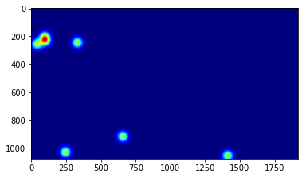

```python
# 可视化 密度图
print(k.shape)
groundtruth = np.asarray(k)
# groundtruth = groundtruth.resize((80,60))
print(groundtruth.shape)
plt.imshow(groundtruth,cmap=CM.jet)
print("Sum = " ,np.sum(groundtruth))
# print(groundtruth[0][59:100])
```

```python
#图片操作
def picture_opt(img,ann):
    size_x,size_y = img.size
    train_img_size = (640,480)
    img = img.resize(train_img_size,Image.ANTIALIAS)
    img = np.array(img)
    img = img / 255.0

    gt = []
    for b_l in range(len(ann)):
        # 假设人体是使用方框标注的，通过求均值的方法将框变为点
        if 'w' in ann[b_l].keys():
            x = (ann[b_l]['x']+(ann[b_l]['x']+ann[b_l]['w']))/2
            y = ann[b_l]['y']+20
            x = (x*640/size_x)/8
            y = (y*480/size_y)/8
            gt.append((x,y))
        else:
            x = ann[b_l]['x']
            y = ann[b_l]['y']
            x = (x*640/size_x)/8
            y = (y*480/size_y)/8
            gt.append((x,y))
    # 返回resize后的图片 和 gt
    return img,gt
```

```python
#密度图处理
def ground(img,gt):
    imgs = img
    x = imgs.shape[0]/8
    y = imgs.shape[1]/8
    k = np.zeros((int(x),int(y)))

    for i in range(0,len(gt)):
        if int(gt[i][1]) < int(x) and int(gt[i][0]) < int(y):
            k[int(gt[i][1]),int(gt[i][0])]=1

        # generate density map
    k = gaussian_filter_density(k)
    return k
```

```
(928, 576)
(480, 640, 3)
[(28.879310344827587, 25.9375), (24.74137931034483, 19.791666666666668)]
```

[figure not shown]

```python
#方框变点
qt = []
img = Image.open(content['annotations'][2]['name'])
ann = content['annotations'][2]['annotation']
print(img.size)
temp = img.resize((80, 60),Image.ANTIALIAS)
im,qt = picture_opt(img,ann)
print(im.shape)
print(qt)
for a in range(len(qt)):
    for x in range(temp.size[0]):
        for y in range(temp.size[1]):
            if(x > (qt[a][0]-1) and x < (qt[a][0]+1) and y > qt[a][1]-1 and y < (qt[a][1]+1)):  #取坐标范围正负10的像素
                temp.putpixel((x,y),(255,0,0))           #对所取范围的像素变成红色
plt.imshow(temp)
k = ground(im,qt)
```

```python
# 定义数据生成器
def train_set():
    def inner():
        for ig_index in range(2000):                  #遍历所有图片
            if len(content['annotations'][ig_index]['annotation']) == 2:continue
            if len(content['annotations'][ig_index]['annotation']) == 3:continue
            if content['annotations'][ig_index]['name'] == 'train/8538edb45aaf7df78336aa5b49001be6.jpg':continue
            if content['annotations'][ig_index]['name'] == 'train/377df0a7a9abc44e840e938521df3b54.jpg':continue
            if content['annotations'][ig_index]['ignore_region']:                      #把忽略区域都用像素为0填上
                ig_list = []                                                           #存放忽略区1的数据
                ig_list1 = []                                                          #存放忽略区2的数据
                # print(content['annotations'][ig_index]['ignore_region'])
                if len(content['annotations'][ig_index]['ignore_region'])==1:           #因为每张图的忽略区域最多2个，这里是为1的情况
                    # print('ig1',ig_index)
                    ign_rge = content['annotations'][ig_index]['ignore_region'][0]       #取第一个忽略区的数据
                    for ig_len in range(len(ign_rge)):                                   #遍历忽略区坐标个数，组成多少变型
                        ig_list.append([ign_rge[ig_len]['x'],ign_rge[ig_len]['y']])       #取出每个坐标的x,y然后组成一个小列表放到ig_list
                    ig_cv_img = cv2.imread(content['annotations'][ig_index]['name'])      #用cv2读取一张图片
                    pts = np.array(ig_list,np.int32)                                      #把ig_list转成numpy.ndarray数据格式，为了填充需要
                    cv2.fillPoly(ig_cv_img,[pts],(0,0,0),cv2.LINE_AA)                           #使用cv2.fillPoly方法对有忽略区的图片用像素为0填充

                    ig_img = Image.fromarray(cv2.cvtColor(ig_cv_img,cv2.COLOR_BGR2RGB))   #cv2转PIL

                    ann = content['annotations'][ig_index]['annotation']          #把所有标注的信息读取出来

                    ig_im,gt = picture_opt(ig_img,ann)
                    k = ground(ig_im,gt)

                    groundtruth = np.asarray(k)
                    groundtruth = groundtruth.T.astype('float32')
                    ig_im = ig_im.transpose().astype('float32')
                    yield ig_im,groundtruth

                if len(content['annotations'][ig_index]['ignore_region'])==2:           #有2个忽略区域
                    # print('ig2',ig_index)
                    ign_rge = content['annotations'][ig_index]['ignore_region'][0]
                    ign_rge1 = content['annotations'][ig_index]['ignore_region'][1]
                    for ig_len in range(len(ign_rge)):
                        ig_list.append([ign_rge[ig_len]['x'],ign_rge[ig_len]['y']])
                    for ig_len1 in range(len(ign_rge1)):
                        ig_list1.append([ign_rge1[ig_len1]['x'],ign_rge1[ig_len1]['y']])
                    ig_cv_img2 = cv2.imread(content['annotations'][ig_index]['name'])
                    pts = np.array(ig_list,np.int32)
                    pts1 = np.array(ig_list1,np.int32)
                    cv2.fillPoly(ig_cv_img2,[pts],(0,0,0),cv2.LINE_AA)
                    cv2.fillPoly(ig_cv_img2,[pts1],(0,0,0),cv2.LINE_AA)

                    ig_img2 = Image.fromarray(cv2.cvtColor(ig_cv_img2,cv2.COLOR_BGR2RGB))   #cv2转PIL

                    ann = content['annotations'][ig_index]['annotation']          #把所有标注的信息读取出来

                    ig_im,gt = picture_opt(ig_img2,ann)
                    k = ground(ig_im,gt)
                    k = np.zeros((int(ig_im.shape[0]/8),int(ig_im.shape[1]/8)))

                    groundtruth = np.asarray(k)
                    groundtruth = groundtruth.T.astype('float32')
                    ig_im = ig_im.transpose().astype('float32')
                    yield ig_im,groundtruth

            else:
                # print('else',ig_index,content['annotations'][ig_index]['name'])
                img = Image.open(content['annotations'][ig_index]['name'])
                ann = content['annotations'][ig_index]['annotation']          #把所有标注的信息读取出来

                im,gt = picture_opt(img,ann)
                k = ground(im,gt)

                groundtruth = np.asarray(k)
                groundtruth = groundtruth.T.astype('float32')
                im = im.transpose().astype('float32')
                yield im,groundtruth
    return inner
```

batch_size不要设置太大，因为网络的输入为640 * 480，属于一个比较大的输入了，因此网络的参数较多，如果batch_size设置太大的话，会导致显存不够，因此这里推荐batch_size设置的小一点

```python
BATCH_SIZE= 2     #每次取10张
# 设置训练reader
train_reader = paddle.batch(
    paddle.reader.shuffle(
        train_set(), buf_size=5),
    batch_size=BATCH_SIZE)
```

```python
def crowd_deconv_without_bn(img):
    x = img

    x = fluid.layers.conv2d(input=x, num_filters=64, filter_size=3, padding=1, act='relu')
    x = fluid.layers.batch_norm(input=x, act='relu')
    x = fluid.layers.conv2d(input=x, num_filters=64, filter_size=3, padding=1, act='relu')
    print('3-64-2',x.shape)
    x = fluid.layers.pool2d(input=x, pool_size=2, pool_stride=2)
    x = fluid.layers.dropout(x=x, dropout_prob=0.25)
    print('pool',x.shape)

    x = fluid.layers.conv2d(input=x, num_filters=128, filter_size=3, padding=1, act=None)
    x = fluid.layers.batch_norm(input=x, act='relu')
    x = fluid.layers.conv2d(input=x, num_filters=128, filter_size=3, padding=1, act='relu')
    print('3-128-2',x.shape)
    x = fluid.layers.pool2d(input=x, pool_size=2, pool_stride=2)
    x = fluid.layers.dropout(x=x, dropout_prob=0.25)

    x = fluid.layers.conv2d(input=x, num_filters=256, filter_size=3, padding=1, act='relu')
    x = fluid.layers.batch_norm(input=x, act='relu')
    x = fluid.layers.conv2d(input=x, num_filters=256, filter_size=3, padding=1, act=None)
    x = fluid.layers.batch_norm(input=x, act='relu')
    x = fluid.layers.conv2d(input=x, num_filters=256, filter_size=3, padding=1, act='relu')
    print('3-256-3',x.shape)
    x = fluid.layers.pool2d(input=x, pool_size=2, pool_stride=2)
    x = fluid.layers.dropout(x=x, dropout_prob=0.5)

    # x = fluid.layers.conv2d(input=x, num_filters=512, filter_size=3, padding=1, act='relu')
    # x = fluid.layers.conv2d(input=x, num_filters=512, filter_size=3, padding=1, act='relu')
    # x = fluid.layers.conv2d(input=x, num_filters=512, filter_size=3, padding=1,act='relu' )

    # x = fluid.layers.pool2d(input=x, pool_size=3, pool_stride=1, pool_padding=1)
    # x = fluid.layers.pool2d(input=x, pool_size=2, pool_stride=2)
    # x = fluid.layers.dropout(x=x, dropout_prob=0.5)

    x = fluid.layers.conv2d(input=x, num_filters=512, filter_size=3, padding=1, act='relu')
    x = fluid.layers.dropout(x=x, dropout_prob=0.5)
    x = fluid.layers.conv2d(input=x, num_filters=512, filter_size=3, padding=1, act='relu')
    x = fluid.layers.dropout(x=x, dropout_prob=0.5)
    x = fluid.layers.conv2d(input=x, num_filters=512, filter_size=3, padding=1)
    x = fluid.layers.batch_norm(input=x, act=None)
    print('3-512-3',x.shape)
    # x = fluid.layers.pool2d(input=x, pool_size=3, pool_stride=2, pool_padding=1)
    # x = fluid.layers.dropout(x=x, dropout_prob=0.5)
    print('clowd_net output shape:',x.shape)

    return x
```

```python
def dilations_cnn(VGG_16_net):
    x = VGG_16_net
    print(x.shape)
    x = fluid.layers.conv2d(input=x, num_filters=512, filter_size=3, padding=2, dilation=2, act='relu')
    x = fluid.layers.dropout(x=x, dropout_prob=0.5)
    x = fluid.layers.conv2d(input=x, num_filters=512, filter_size=3, padding=2, dilation=2, act='relu')
    x = fluid.layers.dropout(x=x, dropout_prob=0.5)
    x = fluid.layers.conv2d(input=x, num_filters=512, filter_size=3, padding=2, dilation=2, act='relu')
    x = fluid.layers.dropout(x=x, dropout_prob=0.5)
    x = fluid.layers.conv2d(input=x, num_filters=256, filter_size=3, padding=2, dilation=2, act='relu')
    x = fluid.layers.dropout(x=x, dropout_prob=0.5)
    x = fluid.layers.conv2d(input=x, num_filters=128, filter_size=3, padding=2, dilation=2, act='relu')
    x = fluid.layers.dropout(x=x, dropout_prob=0.5)
    x = fluid.layers.conv2d(input=x, num_filters=64, filter_size=3, padding=2, dilation=2, act='relu')

    x = fluid.layers.conv2d(input=x, num_filters=1, filter_size=1, act=None)
    print(x.shape)
    return x
```

```python
img_size = [3,640,480]
images = fluid.layers.data(name='images',shape=img_size,dtype='float32')
label = fluid.layers.data(name='label',shape=[1,80,60],dtype='float32')
VGG = crowd_deconv_without_bn(images)
predict = dilations_cnn(VGG)
```

```
3-64-2 (-1, 64, 640, 480)
pool (-1, 64, 320, 240)
3-128-2 (-1, 128, 320, 240)
3-256-3 (-1, 256, 160, 120)
3-512-3 (-1, 512, 80, 60)
clowd_net output shape: (-1, 512, 80, 60)
(-1, 512, 80, 60)
(-1, 1, 80, 60)
```

```python
squar = fluid.layers.square_error_cost(input=predict, label=label)
cost = fluid.layers.sqrt(squar, name=None)
print(cost.shape)
avg_cost = fluid.layers.mean(cost)
print(avg_cost.shape)
```

```
(-1, 1, 80, 60)
(1,)
```

```python
# 创建优化器optimizer，下面列举了2种常用的优化器，不同类型优化器选一即可
# 创建Momentum优化器，并设置学习率(learning_rate)、动量(momentum)
# optimizer = fluid.optimizer.Momentum(
#     learning_rate=0.001,
#     momentum=0.8)
optimizer = fluid.optimizer.AdamOptimizer(learning_rate=1e-6)
# optimizer = fluid.optimizer.SGD(learning_rate=1e-5)
optimizer.minimize(avg_cost)
print('优化')
```

```
优化
```

```python
startup_program = fluid.default_startup_program()
main_program = fluid.default_main_program()
# test_program = fluid.default_main_program().clone(for_test=True)
#optimized = fluid.transpiler.memory_optimize(input_program=fluid.default_main_program(), print_log=False)
```

```python
# 设置训练场所
# use_cuda = False
use_cuda = True
place = fluid.CUDAPlace(0) if use_cuda else fluid.CPUPlace()
# 创建执行器，palce在程序初始化时设定
exe = fluid.Executor(place)
# 初始化执行器
exe.run(startup_program)

feeder = fluid.DataFeeder(feed_list=[images, label],place=place)
#训练保存
model_save_dir = 'renliuyuce_model6'
```

```python
train_prompt = "Train cost"
cost_ploter = Ploter(train_prompt)
def event_handler_plot(ploter_title, step, cost):
    cost_ploter.append(ploter_title, step, cost)
    cost_ploter.plot()
```

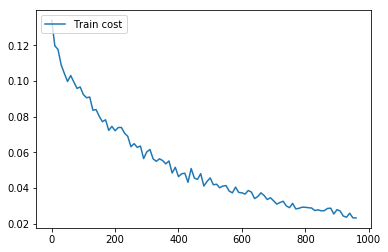

```
[-18.38169, -23.452583] [12.64523, 9.997544] -41.834267 22.642775
Pass:0, Batch:100, Cost:0.09239
[-21.880314, -23.952175] [6.410203, 14.734348] -45.832497 21.144554
Pass:0, Batch:200, Cost:0.07215
[-2.836212, -13.251526] [4.1453743, 2.919986] -16.087742 7.06536
Pass:0, Batch:300, Cost:0.06027
[3.0028715, -6.644768] [2.9649224, 8.384289] -3.6418972 11.349211
Pass:0, Batch:400, Cost:0.04645
[-2.655464, 0.4543581] [18.172947, 13.879091] -2.201105 32.05204
Pass:0, Batch:500, Cost:0.04574
[2.4434876, 0.3271623] [9.414499, 6.914631] 2.7706506 16.32913
Pass:0, Batch:600, Cost:0.03740
[6.8387213, 1.8385086] [25.979862, 8.131559] 8.67723 34.111423
Pass:0, Batch:700, Cost:0.03291
[0.09824157, 4.4691434] [9.882317, 3.0365481] 4.5673847 12.918865
Pass:0, Batch:800, Cost:0.02928
[4.3824263, 6.360602] [6.8606105, 70.86368] 10.743028 77.72429
Pass:0, Batch:900, Cost:0.02796
训练模型保存完成！
V100训练用时：07分23秒
```

```python
# 只训练1个EPOCH，仅仅是跑通流程
from PIL import ImageFile
ImageFile.LOAD_TRUNCATED_IMAGES = True
EPOCH_NUM = 1

# 开始训练

lists = []

step = 0

for epochs in range(EPOCH_NUM):

    # 开始训练

    for batch_id, train_data in enumerate(train_reader()):              #遍历train_reader的迭代器，并为数据加上索引batch_id

        train_cost,sult,lab,vgg = exe.run(program=main_program,      #运行主程序

                             feed=feeder.feed(train_data),              #喂入一个batch的数据

                             fetch_list=[avg_cost,predict,label,VGG])          #fetch均方误差和准确率

        if step % 10 == 0:

            event_handler_plot(train_prompt,step,train_cost[0])

        # print(batch_id)

        if batch_id % 100 == 0:                                   #每100次batch打印一次训练、进行一次测试

            p = [np.sum(pre) for pre in sult]

            l = [np.sum(pre) for pre in lab]

            print(p,l,np.sum(sult),np.sum(lab))

            print('Pass:%d, Batch:%d, Cost:%0.5f' % (epochs, batch_id, train_cost[0]))

        step += 1





    # 保存模型

    if model_save_dir is not None:

        fluid.io.save_inference_model(model_save_dir, ['images'], [predict], exe)


print('训练模型保存完成！')

end = time.time()

print(time.strftime('V100训练用时：%M分%S秒',time.localtime(end-start)))
```

```
[[0.00119604 0.00100309 0.00136946 ... 0.00096557 0.0011055  0.0011094 ]
 [0.000992   0.00092241 0.00118887 ... 0.00087586 0.00098534 0.00102252]
 [0.00174946 0.0017056  0.00164599 ... 0.00118128 0.00113632 0.00122333]
 ...
 [0.00134351 0.0014324  0.00132343 ... 0.00121934 0.00140633 0.00150016]
 [0.00113674 0.00115063 0.00129833 ... 0.00127432 0.00120324 0.00129394]
 [0.00115839 0.00113954 0.00146925 ... 0.00143392 0.00117766 0.00129471]]
7.113414
```

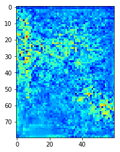

```python
#测试图片
import numpy as np
from PIL import Image
import paddle.fluid as fluid
import matplotlib.pyplot as plt
import zipfile

test_zfile = zipfile.ZipFile("/home/aistudio/data/data1917/test_new.zip")
l_test = []
for test_fname in test_zfile.namelist()[1:]:
    l_test.append(test_fname)

test_img = Image.open(l_test[0])

plt.imshow(test_img)
test_img = test_img.resize((640,480))
test_im = np.array(test_img)
test_im = test_im / 255.0
test_im = test_im.transpose().reshape(1,3,640,480).astype('float32')

use = True
place1 = fluid.CUDAPlace(0) if use else fluid.CPUPlace()
# 定义一个executor
infer_exe = fluid.Executor(place1)

inference_scope = fluid.core.Scope()   #要想运行一个网络，需要指明它运行所在的域，确切的说： exe.Run(&scope) 。

model_save_dir = 'renliuyuce_model6'

with fluid.scope_guard(inference_scope):
    #获取训练好的模型
    #从指定目录中加载 推理model(inference model)
    [inference_program,                           # 预测用的program
     feed_target_names,                           # 是一个str列表，它包含需要在推理 Program 中提供数据的变量的名称。
     fetch_targets] = fluid.io.load_inference_model(model_save_dir, #fetch_targets：是一个 Variable 列表，从中我们可以得到推断结果。
                                                    infer_exe)      #infer_exe: 运行 inference model的 executor

    results = infer_exe.run(inference_program,                 #运行预测程序
                            feed={feed_target_names[0]: test_im},  #喂入要预测的img
                            fetch_list=fetch_targets)          #得到推测结果

    result = results[0][0][0]
    print(result)
    plt.imshow(result,cmap=CM.jet)

    print(np.sum(results[0]))
```

```python
#测试输出保存CSV，仅测试了100个样本，输出结果每行代表一个样本，分布为标号 样本名称 人流密度

import numpy as np
from PIL import Image
import paddle.fluid as fluid
import matplotlib.pyplot as plt
import zipfile

test_zfile = zipfile.ZipFile("/home/aistudio/data/data1917/test_new.zip")
l_test = []
for test_fname in test_zfile.namelist()[1:]:
    # print(fname)
    l_test.append(test_fname)

use = True
place1 = fluid.CUDAPlace(0) if use else fluid.CPUPlace()
infer_exe = fluid.Executor(place1)

inference_scope = fluid.core.Scope()

model_save_dir = 'renliuyuce_model6'

data_dict = {}
with fluid.scope_guard(inference_scope):
    [inference_program,
     feed_target_names,
     fetch_targets] = fluid.io.load_inference_model(model_save_dir,infer_exe)

    for index in range(100):
        test_img = Image.open(l_test[index])
        test_img = test_img.resize((640,480))
        test_im = np.array(test_img)
        test_im = test_im / 255.0
        test_im = test_im.transpose().reshape(1,3,640,480).astype('float32')
        l_test[index] = l_test[index].lstrip('test').lstrip('/')

        results = infer_exe.run(inference_program,                 #运行预测程序
                            feed={feed_target_names[0]: test_im},  #喂入要预测的img
                            fetch_list=fetch_targets)          #得到推测结果

        # print(people)
        people = np.sum(results)
        print(index,l_test[index],int(people))
        data_dict[l_test[index]]=int(people)

import csv

with open('results7.csv', 'w') as csvfile:

    fieldnames = ['id', 'predicted']

    writer = csv.DictWriter(csvfile, fieldnames=fieldnames)

    writer.writeheader()

    for k,v in data_dict.items():

        writer.writerow({'id': k, 'predicted':v})
```

```
0 0030cbde7ebf96cb48653e522c5552ce.jpg 7
1 00329c08e0da69cabc1f9e6c717620d4.jpg 7
2 003db6ca3fcbf144ec84c37190ff8154.jpg 7
3 0044fea731a14d12d6cb20e35ca1b0a4.png 6
4 0056290deda7b11e6af88400b7666109.jpg 7
5 00adfe98f8f1e6abf5a96598430defd7.jpg 6
6 00bdc7546131db72333c3e0ac9cf5478.jpg 7
7 00c11635b4a5923a2955b27351d6eea5.jpg 6
8 00cf364151827d055a17206ab7d5e7cd.jpg 6
9 00ecc910746481026ab8f5e6da0e0567.jpg 7
10 00fd80079c5c80d6f2e018228e2057c7.jpg 7
11 010092130f7143e7c49dbf71dd260480.jpg 6
12 0106232fa79db9767b9c2448d98cb32e.jpg 7
13 010c5cada96fd0553c3a19821bf15698.jpg 7
14 011aae8483f505156f45260636f5643c.jpg 7
```

[output cut: 85 more lines]